# Statistical Analysis

Lyttia Cancinos-McManus

September 2, 2018

```r
library(tidyverse)
crimes4 <- read.csv("crimes4.csv")
```

1. Counts: Total number of crimes per zip code, ordered from highest crime count to lowest.Someone buying property might be interested in this plot.

```r
crime_count_by_zip <- crimes4 %>% count(zipcode)
crime_count_by_zip
```

```
## # A tibble: 101 x 2
##    zipcode     n
##      <int> <int>
##  1   85003  1986
##  2   85004  2112
##  3   85006  3412
##  4   85007  2636
##  5   85008  8203
##  6   85009  7258
##  7   85012  1106
##  8   85013  3752
##  9   85014  2947
## 10   85015  8965
## # ... with 91 more rows
```

```r
zipcodes <- table(crimes4$zipcode)
zipcodes
```

```
##
## 85003 85004 85006 85007 85008 85009 85012 85013 85014 85015 85016 85017
##  1986  2112  3412  2636  8203  7258  1106  3752  2947  8965  4910  6852
## 85018 85019 85020 85021 85022 85023 85024 85027 85028 85029 85031 85032
##  3366  3948  3736  5651  4538  5018  1179  3638   955  5192  3944  5450
## 85033 85034 85035 85037 85040 85041 85042 85043 85044 85045 85048 85050
##  5411  3511  6142  3868  4844  7110  4505  5645  2455   103  1115  1286
## 85051 85053 85054 85083 85085 85086 85087 85201 85202 85203 85204 85210
##  7096  2577   697   410  1240   442   108     3     9     1     3     5
## 85212 85213 85215 85224 85225 85226 85233 85234 85248 85250 85251 85253
##     1     4     2     2     7     3     1     2     1     1    72    51
## 85254 85255 85257 85258 85260 85266 85268 85281 85282 85283 85286 85290
##  1834    56     4     2    12     1     1    10     6     3     2     1
## 85295 85296 85301 85302 85303 85304 85305 85306 85307 85308 85310 85323
##     2     3    46    18    15   367     3   571   269  1321   450     9
## 85326 85331 85335 85337 85338 85339 85345 85351 85353 85355 85363 85381
##     2   371     1     1     3  3203     7     1  1701     1     1     1
## 85382 85383 85392 85395 85396
##     2     4     9     2    12
```

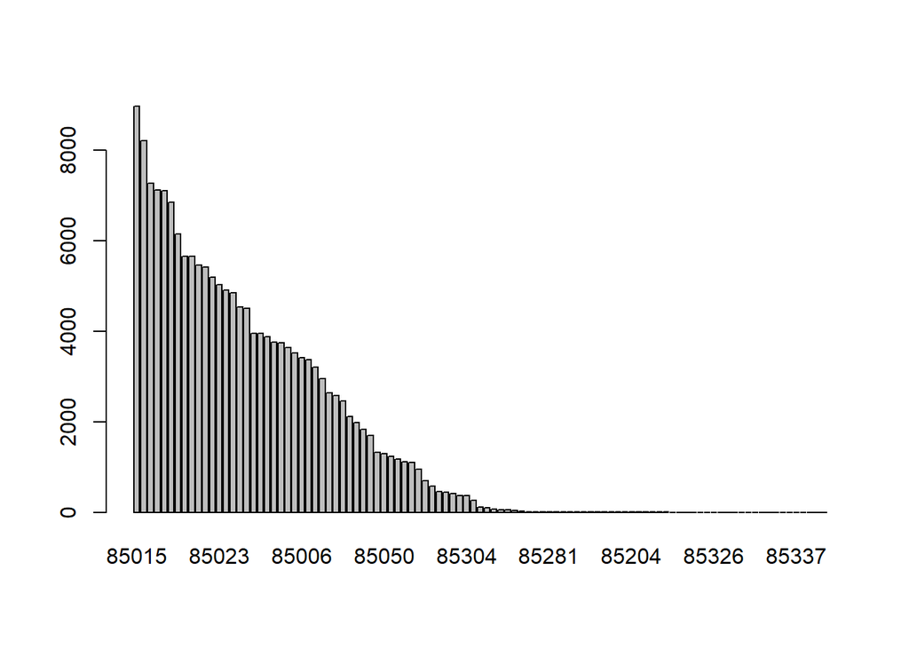

```r
barplot(zipcodes[order(zipcodes, decreasing = TRUE)])
```

Total number of each category of crime.

```r
crime_count_by_category <- crimes4 %>% count(category)
crime_count_by_category
```

```
## # A tibble: 9 x 2
##   category                                  n
##   <fct>                                 <int>
## 1 AGGRAVATED ASSAULT                    12486
## 2 ARSON                                   957
## 3 BURGLARY                              29445
## 4 DRUG OFFENSE                          12941
## 5 LARCENY-THEFT                         85675
## 6 MOTOR VEHICLE THEFT                   18294
## 7 MURDER AND NON-NEGLIGENT MANSLAUGHTER   360
## 8 RAPE                                   2389
## 9 ROBBERY                                7268
```

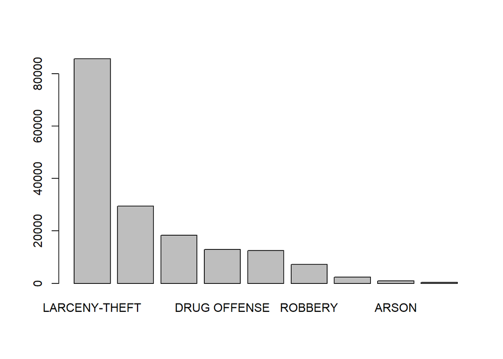

```r
categories <- table(crimes4$category)
barplot(categories[order(categories, decreasing = TRUE)])
```

Total number of each category of crime in zip code with highest crime count.

```r
crimes85015 <- crimes4 %>% filter(zipcode == 85015)
crimes85015 %>% count(category)
```

```
## # A tibble: 9 x 2
##   category                                  n
##   <fct>                                 <int>
## 1 AGGRAVATED ASSAULT                      630
## 2 ARSON                                    67
## 3 BURGLARY                               1375
## 4 DRUG OFFENSE                            766
## 5 LARCENY-THEFT                          4773
## 6 MOTOR VEHICLE THEFT                     717
## 7 MURDER AND NON-NEGLIGENT MANSLAUGHTER    27
## 8 RAPE                                     97
## 9 ROBBERY                                 513
```

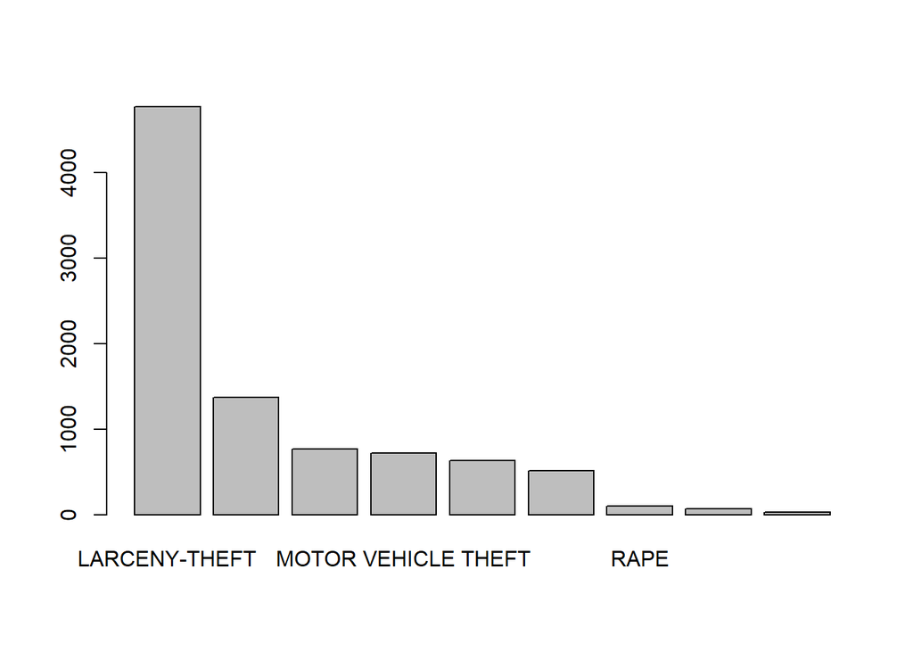

```r
categories85015 <- table(crimes85015$category)
barplot(categories85015[order(categories85015, decreasing = TRUE)])
```

Number of crimes each month in 2017 and 2016.

```r
crimes2017 <- crimes4 %>% filter(year == 2017)
crimes2016 <- crimes4 %>% filter(year == 2016)
crimes2017 %>% count(month)
```

```
## # A tibble: 12 x 2
##    month     n
##    <int> <int>
##  1     1  5558
##  2     2  5035
##  3     3  5415
##  4     4  5346
##  5     5  5684
##  6     6  5538
##  7     7  5685
##  8     8  5704
##  9     9  5336
## 10    10  5807
## 11    11  5400
## 12    12  5503
```

```r
crimes2016 %>% count(month)
```

```
## # A tibble: 12 x 2
##    month     n
##    <int> <int>
##  1     1  5302
##  2     2  4758
##  3     3  5121
##  4     4  5290
##  5     5  5268
##  6     6  5288
##  7     7  5169
##  8     8  5471
##  9     9  5286
## 10    10  5369
## 11    11  5302
## 12    12  5720
```

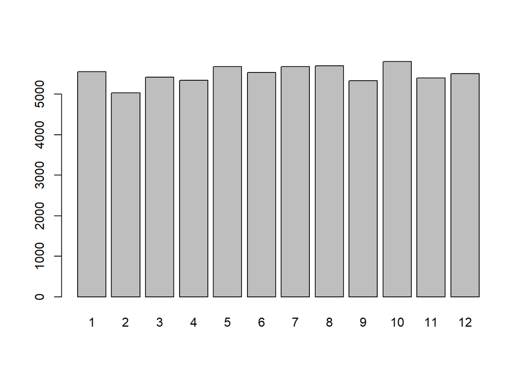

```r
months2017 <- table(crimes2017$month)
months2016 <- table(crimes2016$month)
barplot(months2017)
```

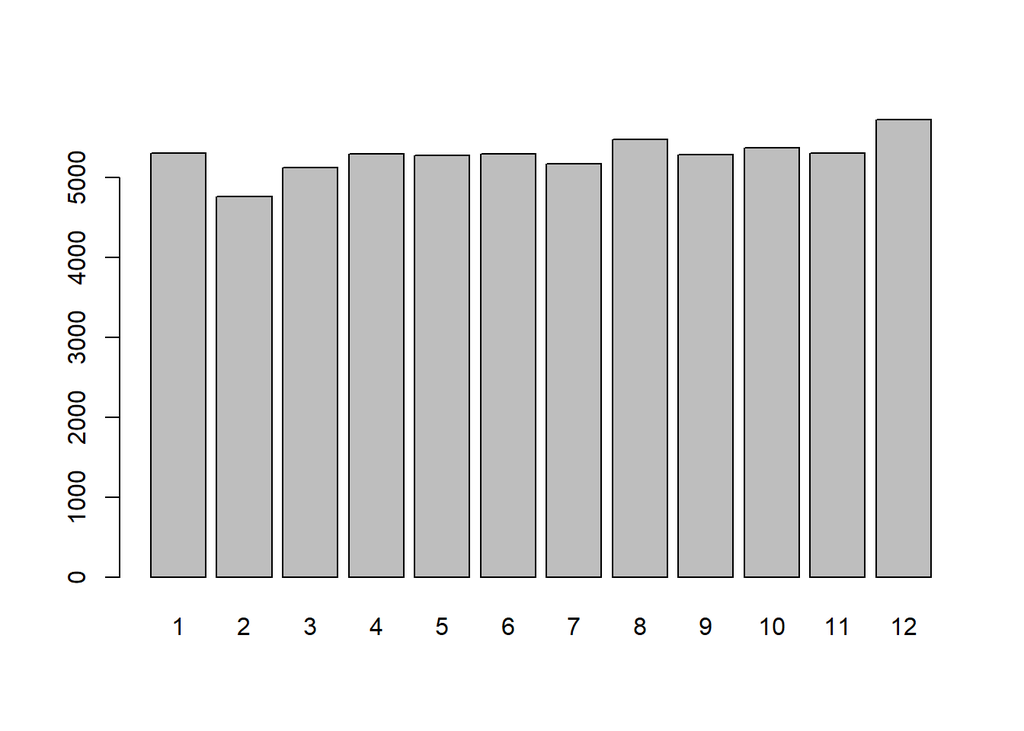

```r
barplot(months2016)
```

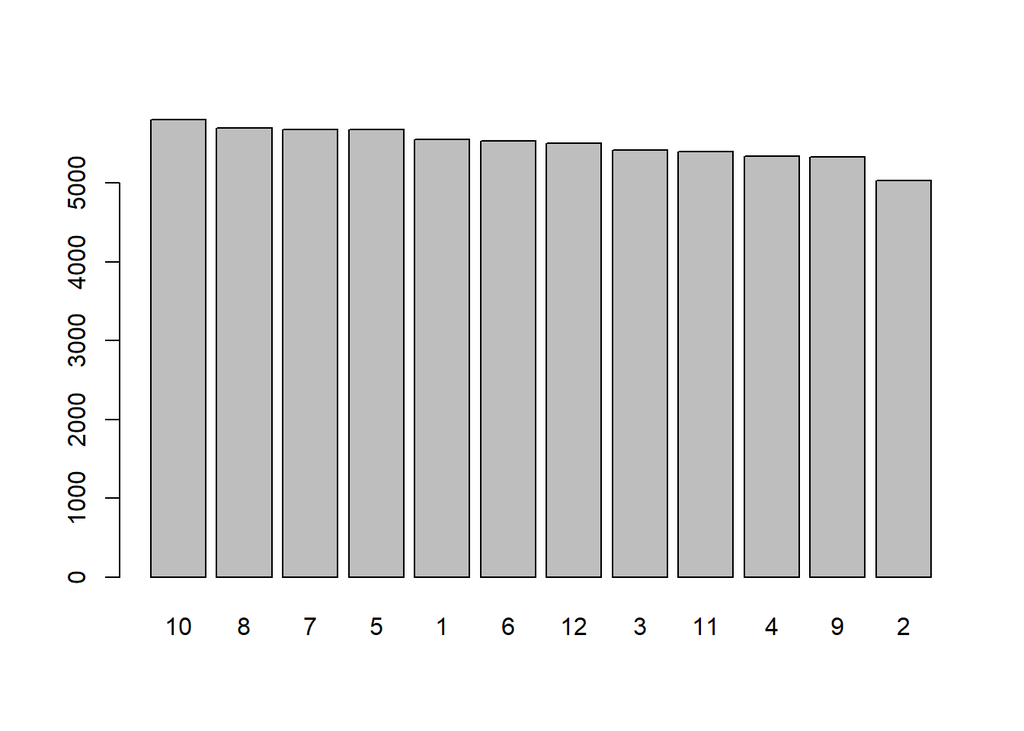

```r
barplot(months2017[order(months2017, decreasing = TRUE)])
```

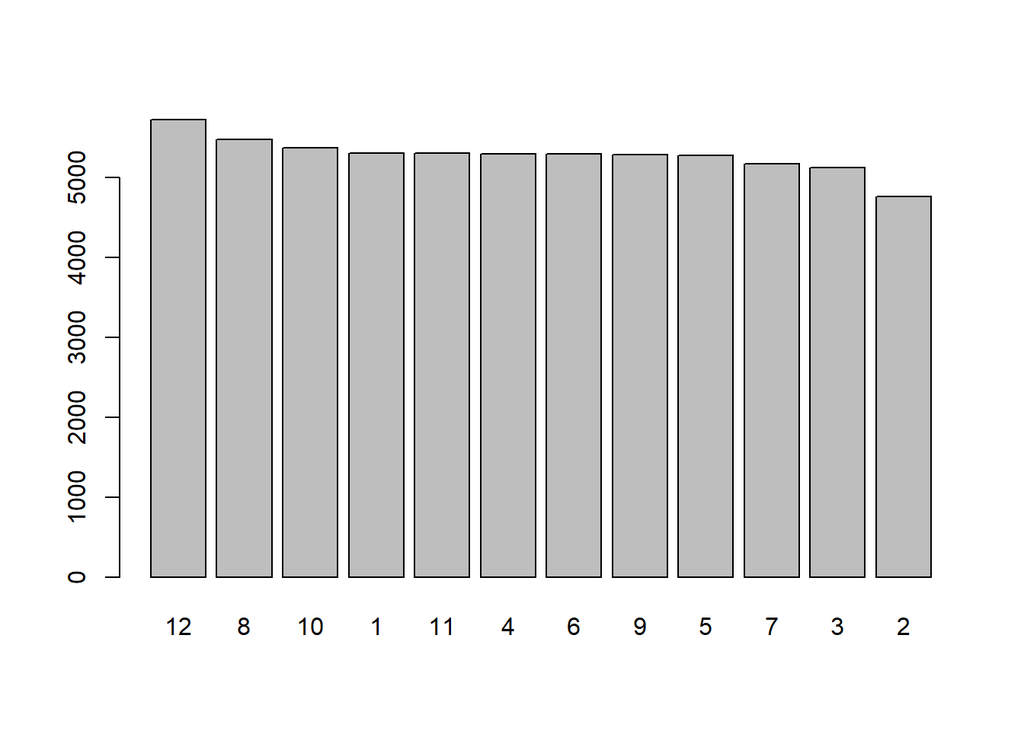

```r
barplot(months2016[order(months2016, decreasing = TRUE)])
```

2. Trends (high, low, increase, decrease, anomalies):

Zip code 85015 has the highest crime count at almost 9000 crimes (8965).

Multiple zip codes have only 1 crime… should these zips be included?

A map would better show where the crimes are being reported and trends, but I do not have exact locations (lat/long).

3. Bar plot/ histogram:

```r
# install.packages("ggplot2")
library(ggplot2)
```

Are any categories more prevelant at a certain time of the month?

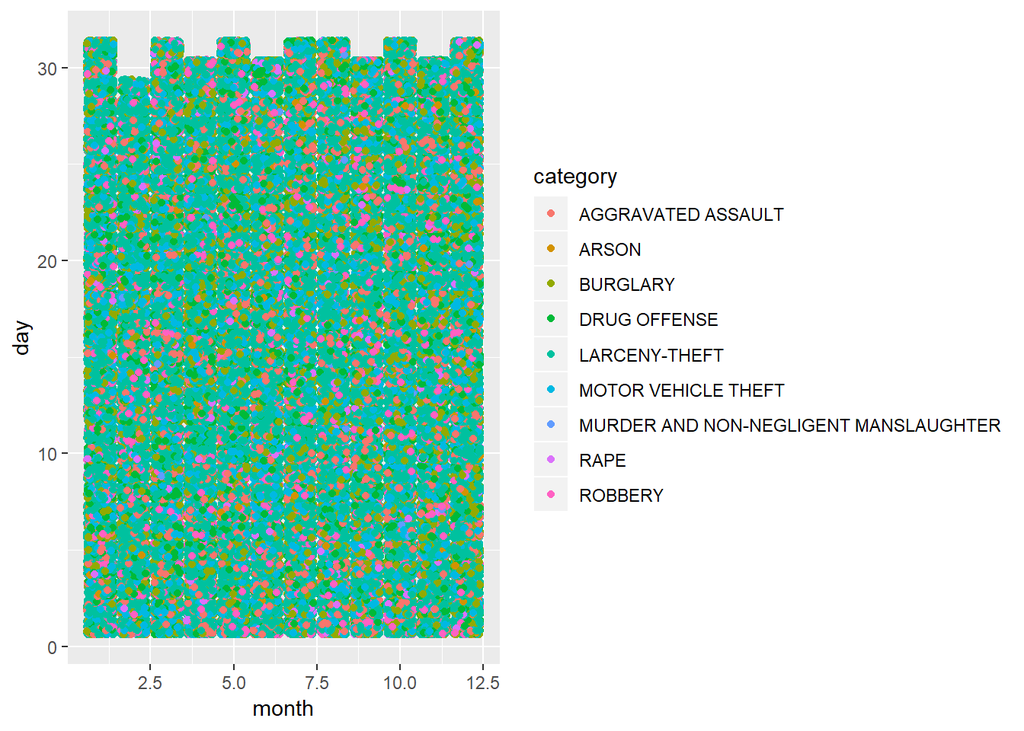

```r
ggplot(crimes4, aes(x = month, y= day, color = category)) +
  geom_jitter(alpha = 1)
```

Does overall crime count increase or decrease as property values increase? Property values need to be binned.

4. Comparisons: Compare the amounts of theft/burglaries vs violent crimes in each zip code ordered by property value.

5. Can you make a time-series plot? x= date, y= crime count

6.Having made these plots, what are some insights you get from them? Do you see any correlations? Is there a hypothesis you would like to investigate further? What other questions do they lead you to ask?

Limitations: Accounts only for crimes reported to Phoenix PD. There may be many other crimes reported to surrounding cities PDs. Would my model be more accurate if I only included zip codes located in Phoenix boundaries?